# Projekt zaliczeniowy

Mikołaj Leonhardt & Kacper Słoniec

- Porównywane alogrytmy:
  - Metoda wielokrotnego startu (MS)
  - Poszukiwanie przypadkowe (PRS)
- Przeszukiwane funkcje:
  - funkcja Ackleya - $f(x) = -20\cdot\exp({-0.2\cdot\sqrt{(\frac{1}{n}\sum_{i=1}^{n}x_i)}}) - \exp(\frac{1}{n}\sum_{i=1}^{n}\cos(2\pi{\cdot}x_i))$
  - funkcja Rastrigina - $f(x) = 10n + \sum_{i=1}^{n}(x_i^2-10\cos(2{\pi}x_i))$

```r
library(smoof)
```

## Poszukiwanie przypadkowe (Pure Random Search, PRS)

Alogrytm przyjmuje liczbę punktów (sample_size), wymiar (dim), dolną granicę dziedziny (d_lower), górną granicę dziedziny (d_upper) oraz funkcję dla której przeprowadza porównanie (f). Zwraca minimalną uzyskaną wartość wylosowanego punktu.

```r
pure_random_search <- function(sample_size, dim, d_lower, d_upper, f) {
    # creates a list of random vectors
    xs <- replicate(
        sample_size,
        runif(dim, min = d_lower, max = d_upper), simplify = FALSE)
    # applies function to every vector in a list
    ys <- lapply(xs, f)
    min(unlist(ys))
}
```

## Metoda wielokrotnego startu (multi-start, MS)

Alogrytm przyjmuje liczbę punktów (sample_size), wymiar (dim), dolną granicę dziedziny (d_lower), górną granicę dziedziny (d_upper) oraz funkcję dla której przeprowadza porównanie (fn). Algorytm zwraca parę (min_value, avg_counts) gdzie min_value jest najmniejszą znalezioną przez funkcję optim wartością przeszukiwanej funkcji, a avg_counts jest średnią liczbą wywołań przeszukiwanej funkcje przez funkcję optim.

```r
multi_start <- function(sample_size, dim, d_lower, d_upper, fn) {
    xs <- replicate(
        sample_size,
        runif(dim, min = d_lower, max = d_upper), simplify = FALSE)
    ms <- lapply(
        xs,
        function(x){
        optim_result <- optim(x, fn, method = "L-BFGS-B", lower = d_lower, upper = d_upper)
        c(value = optim_result$value, counts = optim_result$counts[[1]])
        })
    values <- sapply(ms, function(x) x["value"])
    counts <- sapply(ms, function(x) x["counts"])
    counts <- na.omit(counts)
    # returns a minimum of found local minimums
    list(min_value = min(unlist(values)), avg_counts = mean(unlist(counts)))
}
```

## Porównywanie algorytmów wybraną funkcją

Algorytm przyjmuje liczbę punktów (sample_size), nazwę funkcji (fn_name) - “ackley” lub “rastrigin” oraz wymiar (dimensions). Algorytm zwraca listę z wylosowanymi wartościami minimalnymi (osobny wektor prs i ms). Algorytm respektuje dziedziny wywoływanych funkcji, które określone są w atrybucie par.set.  
Dla funkcji Ackleya: $x_i \in [−32.768,32.768]$.  
Dla funkcji Rastrigina: $x_i \in [−5.12,5.12]$.

```r
compare_fs <- function(sample_size, fn_name, dimensions) {
    fn <- switch(
        fn_name,
        "ackley" = makeAckleyFunction(dimensions),
        "rastrigin" = makeRastriginFunction(dimensions)
        )

    atts <- attributes(fn)
    domain_lower <- rep(atts$par.set[[1]][[1]]$lower, dimensions)
    domain_upper <- rep(atts$par.set[[1]][[1]]$upper, dimensions)
    ms_points_n <- 100

    result <- list(ms = rep(0, sample_size), prs = rep(0, sample_size))

    avg_prs_result <- 0
    avg_ms_result <- 0
    for (i in 1:sample_size){

        ms_result_list <- multi_start(
        ms_points_n, dimensions, domain_lower, domain_upper, fn)

        result$ms[i] <- ms_result_list$min_value

        prs_points_n <- ceiling(ms_result_list$avg_counts) * ms_points_n
        prs_result <- pure_random_search(prs_points_n, dimensions, domain_lower, domain_upper, fn)

        result$prs[i] <- prs_result
    }

    result
}
```

## Wykonanie porównania

```r
sample_size <- 50
ackley2d <- compare_fs(sample_size, "ackley", 2)
ackley10d <- compare_fs(sample_size, "ackley", 10)
ackley20d <- compare_fs(sample_size, "ackley", 20)

rastrigin2d <- compare_fs(sample_size, "rastrigin", 2)
rastrigin10d <- compare_fs(sample_size, "rastrigin", 10)
rastrigin20d <- compare_fs(sample_size, "rastrigin", 20)
```

## Rysowanie diagramów

Algorytm przyjmuje wektor na podstawie którego rysuje wykresy

```r
draw_diagrams <- function(result) {

    layout(matrix(c(1, 2), 1, 2, byrow = TRUE))

    hist(result$ms, prob = TRUE, breaks=20, col=rgb(1,0,0,0.5),
    main="Metoda wielokrotnego startu", xlab="Wartość minimum", ylab="Gęstość")
    x <- seq(min(result$ms), max(result$ms), length = 40)
    f <- dnorm(x, mean = mean(result$ms), sd = sd(result$ms))
    lines(x, f, col = "black", lwd = 2)

    boxplot(result$ms, col=rgb(1, 0, 0, 0.5), ylab="Częstotliwość")

    print(paste("Średni wynik: ", mean(result$ms)))

    layout(matrix(c(1, 2), 1, 2, byrow = TRUE))

    hist(result$prs, prob = TRUE, breaks=20, col=rgb(0,0,1,0.5),
    main="Poszukiwanie przypadkowe", xlab="Wartość minimum", ylab="Gęstość")
    x <- seq(min(result$prs), max(result$prs), length = 40)
    f <- dnorm(x, mean = mean(result$prs), sd = sd(result$prs))
    lines(x, f, col = "black", lwd = 2)

    boxplot(result$prs, col=rgb(0,0,1,0.5), ylab="Częstotliwość")

    print(paste("Średni wynik: ", mean(result$prs)))
}
```

## Opracowanie wyników

Statystyka różnic między średnimi: $T = \frac{(\overline{PRS} - \overline{MS}) - (m_1 - m_2)}{Sp\cdot\sqrt{\frac{1}{n} + \frac{1}{n}}} \sim t{2n-2}$

Z racji tego, że nie znamy rzeczywistego odchylenia standardowego rozkładu średnich minimów oraz korzystając z Centralnego Twierdzenia Granicznego możemy do wykonania analizy istotności statystycznej $T$ można użyć testu Studenta implemenotwanego przez funkcję t.test.

Hipoteza zerowa: różnica między średnimi jest równa 0.  
Hipoteza alternatywna: różnica między średimi jest różna od zera.

Funkcja t.test wylicza również 95% przedział ufności dla podanej statystyki.

## Funkcja Ackley’a

### 2 wymiary

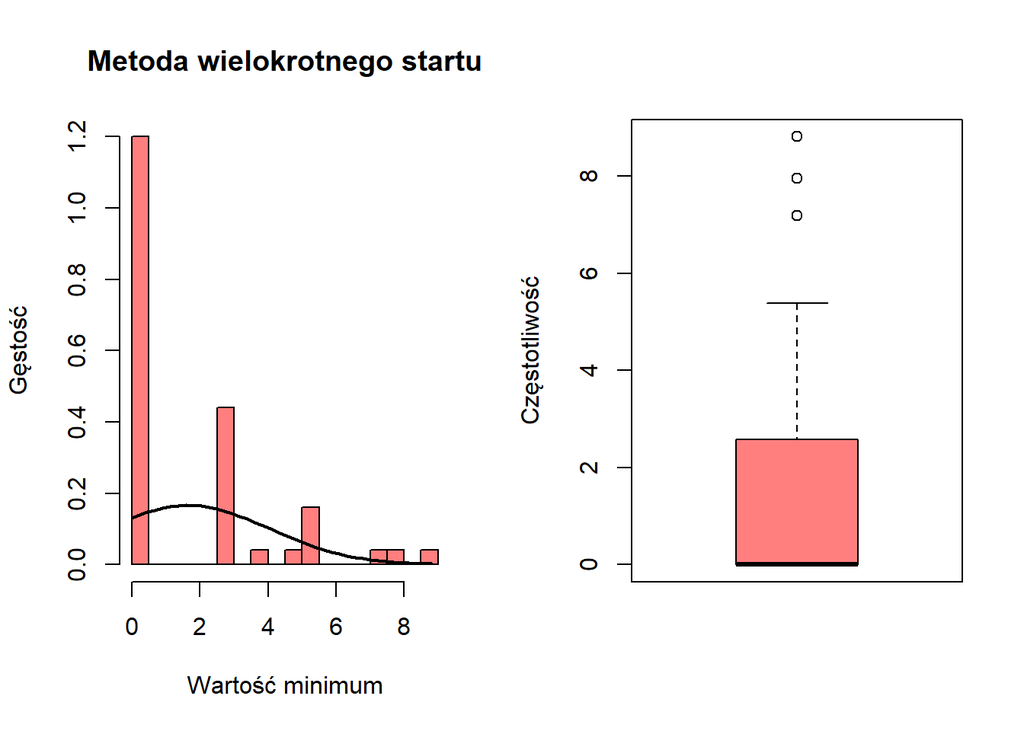

```
## [1] "Średni wynik:  1.64641983418722"
```

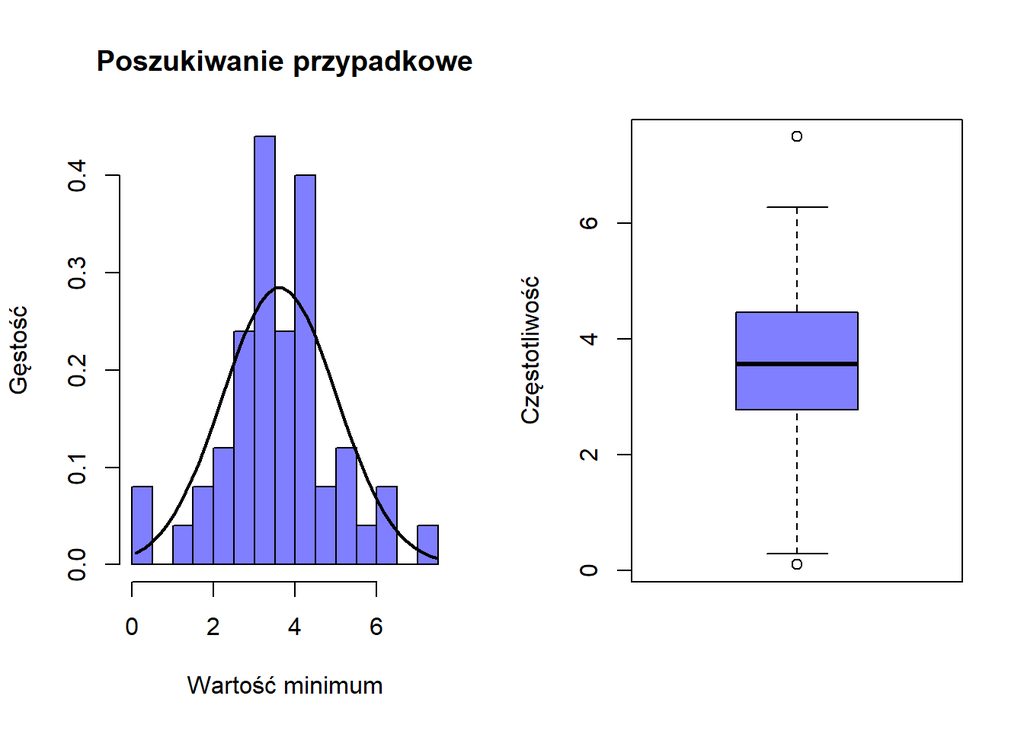

```
## [1] "Średni wynik:  3.61485665082778"
```

```r
draw_diagrams(ackley2d)
```

#### Test Studenta dla różnicy pomiędzy średnimi minimami

```r
ttest <- t.test(ackley2d$ms, ackley2d$prs)
print(ttest)
```

```
##
##  Welch Two Sample t-test
##
## data:  ackley2d$ms and ackley2d$prs
## t = -5.0068, df = 78.805, p-value = 3.305e-06
## alternative hypothesis: true difference in means is not equal to 0
## 95 percent confidence interval:
##  -2.751019 -1.185854
## sample estimates:
## mean of x mean of y
##  1.646420  3.614857
```

### 10 wymiarów

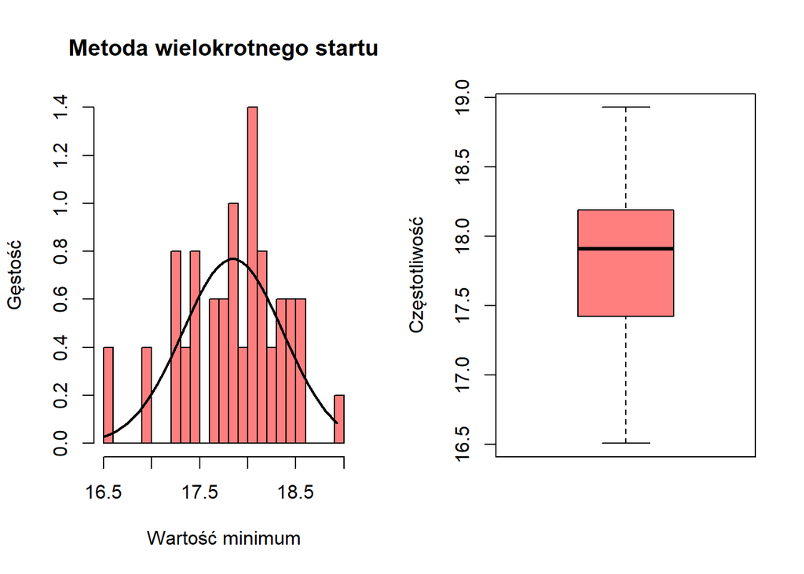

```
## [1] "Średni wynik:  17.8416297816223"
```

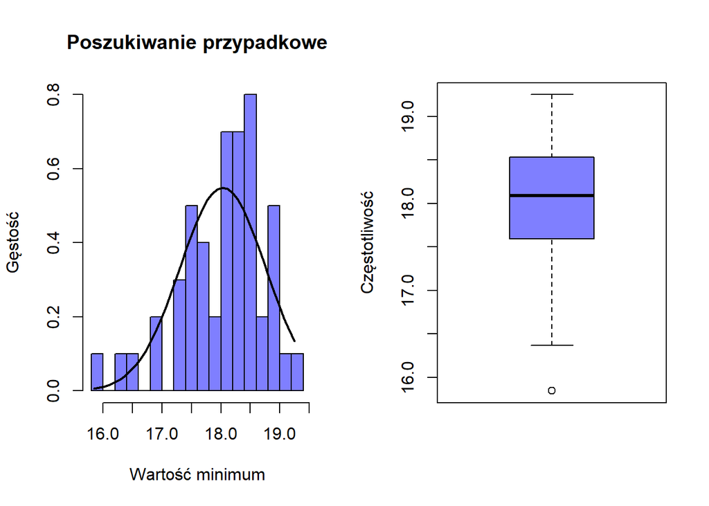

```
## [1] "Średni wynik:  18.0308222911589"
```

```r
draw_diagrams(ackley10d)
```

#### Test Studenta dla różnicy pomiędzy średnimi minimami

```r
ttest <- t.test(ackley10d$ms, ackley10d$prs)
print(ttest)
```

```
##
##  Welch Two Sample t-test
##
## data:  ackley10d$ms and ackley10d$prs
## t = -1.4982, df = 88.678, p-value = 0.1376
## alternative hypothesis: true difference in means is not equal to 0
## 95 percent confidence interval:
##  -0.44011868  0.06173366
## sample estimates:
## mean of x mean of y
##  17.84163  18.03082
```

### 20 wymiarów

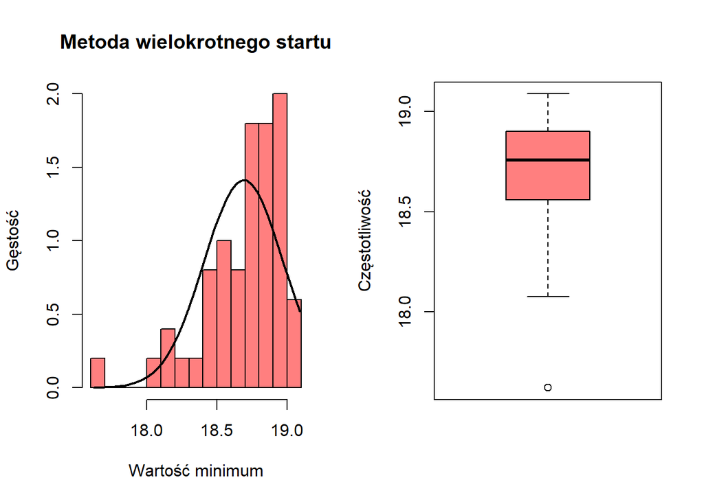

```
## [1] "Średni wynik:  18.6894268970757"
```

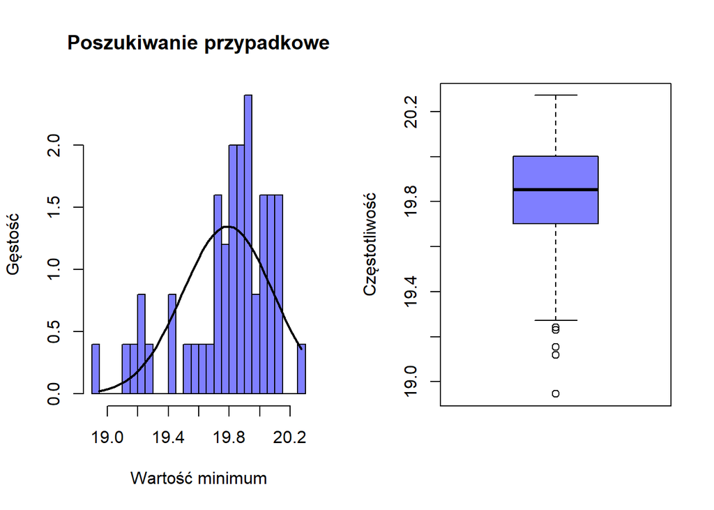

```
## [1] "Średni wynik:  19.7915545785808"
```

```r
draw_diagrams(ackley20d)
```

#### Test Studenta dla różnicy pomiędzy średnimi minimami

```r
ttest <- t.test(ackley20d$ms, ackley20d$prs)
print(ttest)
```

```
##
##  Welch Two Sample t-test
##
## data:  ackley20d$ms and ackley20d$prs
## t = -19.057, df = 97.778, p-value < 2.2e-16
## alternative hypothesis: true difference in means is not equal to 0
## 95 percent confidence interval:
##  -1.2168980 -0.9873574
## sample estimates:
## mean of x mean of y
##  18.68943  19.79155
```

## Funkcja Rastrigin’a

### 2 wymiary

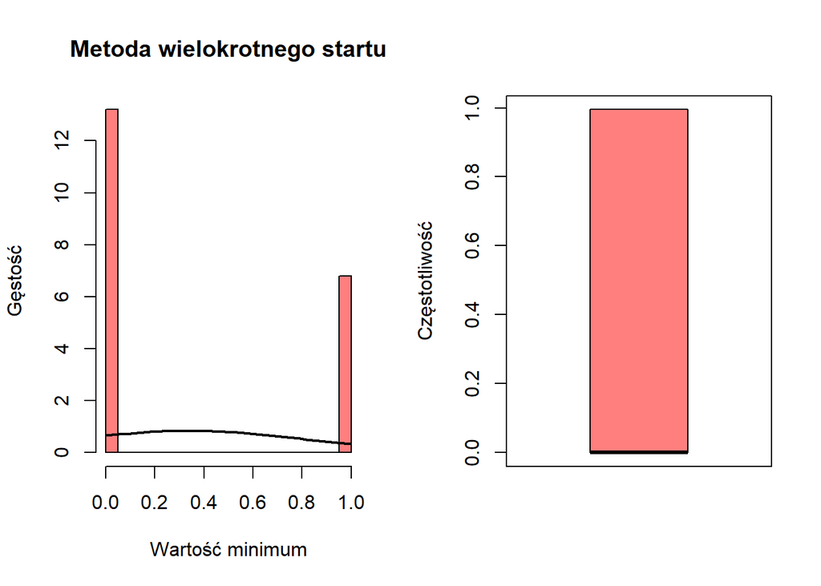

```
## [1] "Średni wynik:  0.338286079411787"
```

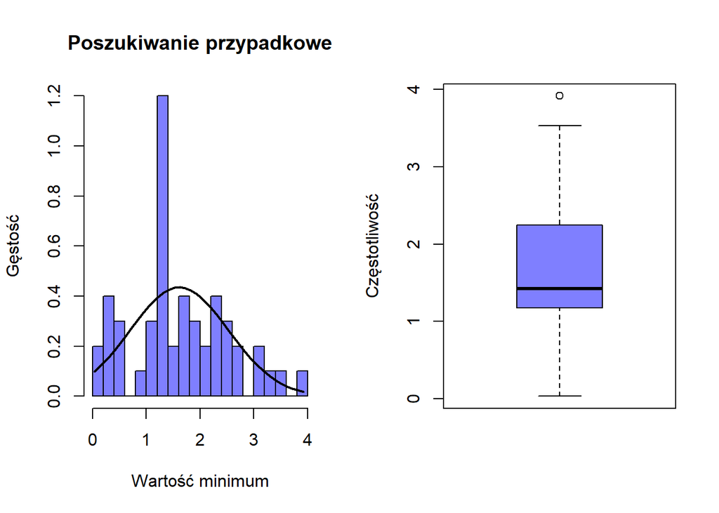

```
## [1] "Średni wynik:  1.61358522557708"
```

```r
draw_diagrams(rastrigin2d)
```

#### Test Studenta dla różnicy pomiędzy średnimi minimami

```r
ttest <- t.test(rastrigin2d$ms, rastrigin2d$prs)
print(ttest)
```

```
##
##  Welch Two Sample t-test
##
## data:  rastrigin2d$ms and rastrigin2d$prs
## t = -8.734, df = 73.667, p-value = 5.48e-13
## alternative hypothesis: true difference in means is not equal to 0
## 95 percent confidence interval:
##  -1.5662647 -0.9843336
## sample estimates:
## mean of x mean of y
## 0.3382861 1.6135852
```

### 10 wymiarów

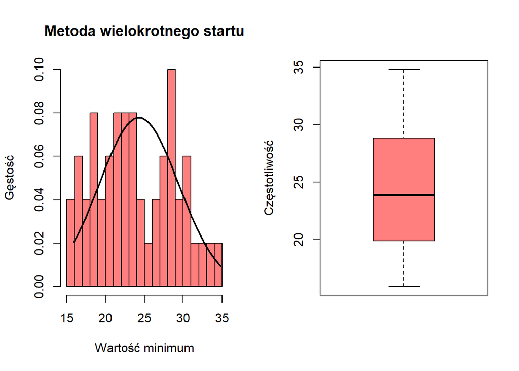

```
## [1] "Średni wynik:  24.2769443576569"
```

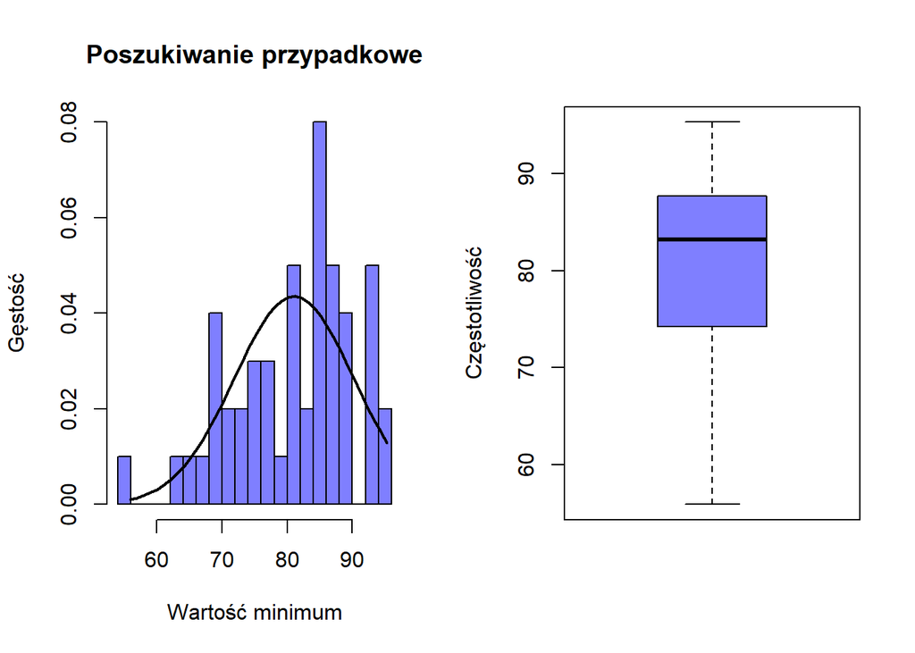

```
## [1] "Średni wynik:  81.0225506031492"
```

```r
draw_diagrams(rastrigin10d)
```

#### Test Studenta dla różnicy pomiędzy średnimi minimami

```r
ttest <- t.test(rastrigin10d$ms, rastrigin10d$prs)
print(ttest)
```

```
##
##  Welch Two Sample t-test
##
## data:  rastrigin10d$ms and rastrigin10d$prs
## t = -38.24, df = 76.956, p-value < 2.2e-16
## alternative hypothesis: true difference in means is not equal to 0
## 95 percent confidence interval:
##  -59.70052 -53.79069
## sample estimates:
## mean of x mean of y
##  24.27694  81.02255
```

### 20 wymiarów

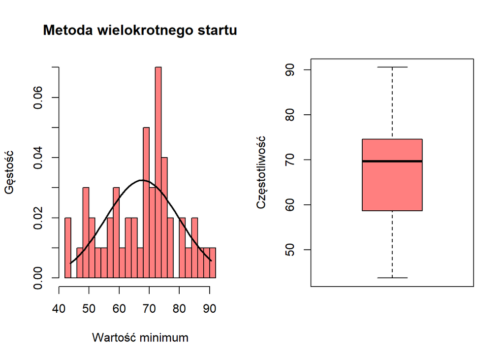

```
## [1] "Średni wynik:  67.6768733653414"
```

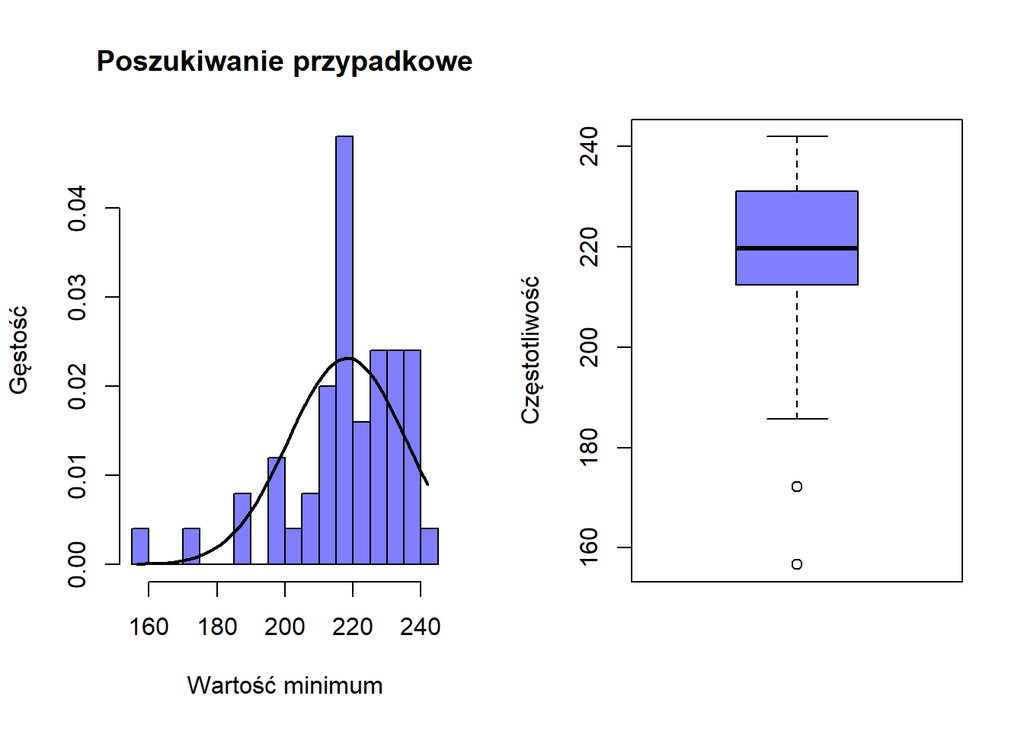

```
## [1] "Średni wynik:  218.254539188932"
```

```r
draw_diagrams(rastrigin20d)
```

#### Test Studenta dla różnicy pomiędzy średnimi minimami

```r
ttest <- t.test(rastrigin20d$ms, rastrigin20d$prs)
print(ttest)
```

```
##
##  Welch Two Sample t-test
##
## data:  rastrigin20d$ms and rastrigin20d$prs
## t = -50.415, df = 88.598, p-value < 2.2e-16
## alternative hypothesis: true difference in means is not equal to 0
## 95 percent confidence interval:
##  -156.5127 -144.6427
## sample estimates:
## mean of x mean of y
##  67.67687 218.25454
```

## Analiza zawartości diagramów

W większości przypadków dane są skupione wokół średniej oraz mediany (których wartości są do siebie zbliżone) i rozproszone wokół nich. Występuje wąski przedział między Q<sub>1</sub> a Q<sub>3</sub>, co oznacza dużą koncentrację danych wokół środka rozkładu. Rozkład danych we wszystkich przypadkach poza dwoma przypomina rozkład naturalny. Dla 2. wymiarów MS (Metoda wielokrotnego startu) daje wyniki rozbieżne, a dane od siebie odstają.

Porównując średnie, w każdym przypadku mniejszy średni wynik zwraca MS, co jest szczególnie widoczne w 2. wymiarach i przy funkcji Rastrigin’a. Różnice średnich dwóch algorytmów są największe przy 10. i 20. wymiarach funkcji Rastrigin’a.

### Wykres zbiorczy

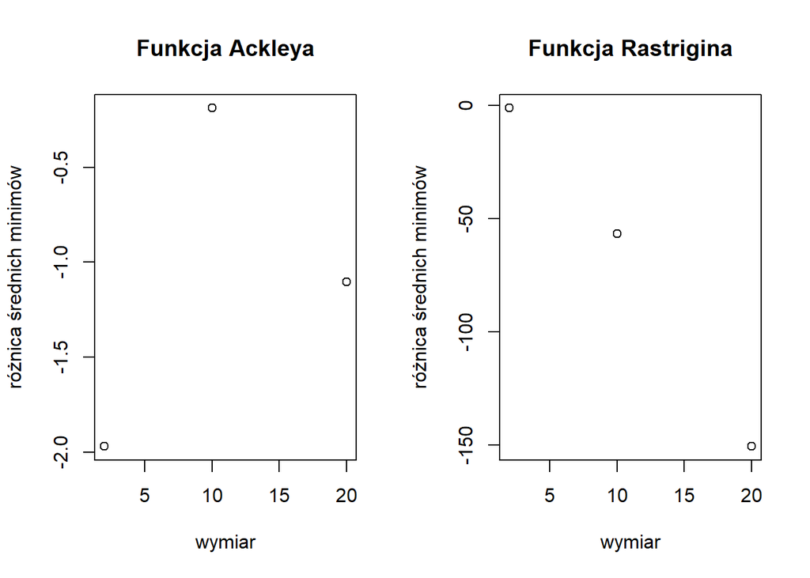

```r
layout(matrix(c(1, 2), 1, 2, byrow = TRUE))


ackley_mean_diff <-
    c(mean(ackley2d$ms), mean(ackley10d$ms), mean(ackley20d$ms)) -
    c(mean(ackley2d$prs), mean(ackley10d$prs), mean(ackley20d$prs))

plot(c(2,10,20), ackley_mean_diff, main = "Funkcja Ackleya", xlab = "wymiar",
ylab = "różnica średnich minimów")

rastrigin_mean_diff <-
    c(mean(rastrigin2d$ms), mean(rastrigin10d$ms), mean(rastrigin20d$ms)) -
    c(mean(rastrigin2d$prs), mean(rastrigin10d$prs), mean(rastrigin20d$prs))

plot(c(2,10,20), rastrigin_mean_diff, main = "Funkcja Rastrigina", xlab = "wymiar",
ylab = "różnica średnich minimów")
```